# R Notebook

#### **0. Logistic Regression Intro.**

- Similar to a linear regression model **where the dependent variable is categorical** rather than numeric (continuous).
- This note focus on **binary** dependent variable (0 or 1). For example, pass/fail, alive/dead, win/lose…etc.
- Approach: the binary logistic model is used to **estimate the probability** (based on odds) of a binary response.

#### **1. Load Churn data, take a look at the file and see summary**

```r
churndata = read.table('/Users/rouhsin_charlotte/Downloads/6312:13_Statistics data/Churndata.dat', header = TRUE)
head(churndata)
```

|  | Age | Loyalty | Dropout |
| --- | --- | --- | --- |
| 1 | 28 | 4 | 0 |
| 2 | 50 | 4 | 0 |
| 3 | 34 | 1 | 1 |
| 4 | 47 | 2 | 0 |
| 5 | 42 | 2 | 0 |
| 6 | 60 | 5 | 0 |

```r
summary(churndata)
```

```
      Age           Loyalty         Dropout
 Min.   :20.00   Min.   :0.000   Min.   :0.000
 1st Qu.:30.00   1st Qu.:1.000   1st Qu.:0.000
 Median :40.00   Median :2.000   Median :0.000
 Mean   :39.77   Mean   :2.404   Mean   :0.316
 3rd Qu.:49.00   3rd Qu.:4.000   3rd Qu.:1.000
 Max.   :60.00   Max.   :5.000   Max.   :1.000
```

#### **2. Build Logistic Regression Model (Choosing Logistic Model)**

- There are other well-defined nonlinear models like Angular, Gompertz, Burr, Urban, **Logistics, and Probit.**
- We are getting **Ln(Odds(DropOut)) = b0 + b1*Age**

```r
churn.logit = glm(Dropout~Age, data = churndata, family = binomial(link = 'logit'))
summary(churn.logit)
```

```
Call:
glm(formula = Dropout ~ Age, family = binomial(link = "logit"),
    data = churndata)

Deviance Residuals:
    Min       1Q   Median       3Q      Max
-1.3651  -0.8783  -0.6223   1.1344   2.1479

Coefficients:
             Estimate Std. Error z value Pr(>|z|)
(Intercept)  1.747680   0.368643   4.741 2.13e-06 ***
Age         -0.065825   0.009607  -6.852 7.30e-12 ***
---
Signif. codes:  0 ‘***’ 0.001 ‘**’ 0.01 ‘*’ 0.05 ‘.’ 0.1 ‘ ’ 1

(Dispersion parameter for binomial family taken to be 1)

    Null deviance: 623.82  on 499  degrees of freedom
Residual deviance: 570.98  on 498  degrees of freedom
AIC: 574.98

Number of Fisher Scoring iterations: 3
```

#### **3. Plot the Model**

```r
AgeVals = seq(0,80,1)
NewData = data.frame(AgeVals)
NewData["PredVal"] = predict(churn.logit, list(Age = NewData$AgeVals), type = "link")
NewData["PredProb"] = exp(NewData$PredVal)/(1+exp(NewData$PredVal))
NewData["PredProb2"] = predict(churn.logit, list(Age = NewData$AgeVals), type = "response")
print(head(NewData))
```

|  | AgeVals | PredVal | PredProb | PredProb2 |
| --- | --- | --- | --- | --- |
| 1 | 0 | 1.747680 | 0.8516600 | 0.8516600 |
| 2 | 1 | 1.681855 | 0.8431501 | 0.8431501 |
| 3 | 2 | 1.616031 | 0.8342470 | 0.8342470 |
| 4 | 3 | 1.550206 | 0.8249435 | 0.8249435 |
| 5 | 4 | 1.484381 | 0.8152334 | 0.8152334 |
| 6 | 5 | 1.418556 | 0.8051120 | 0.8051120 |

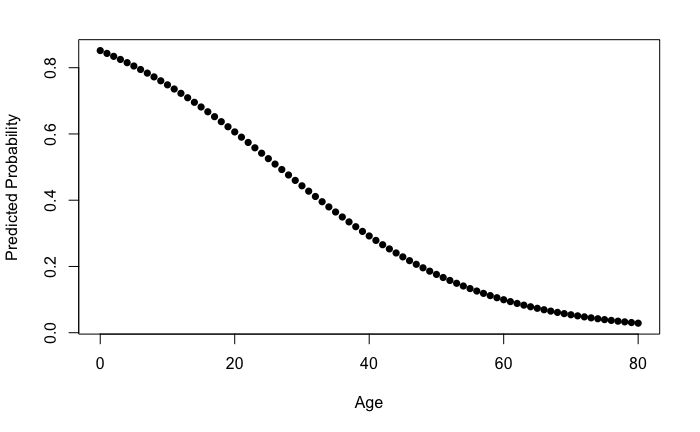

```r
plot(NewData$AgeVals, NewData$PredProb, pch = 16, xlab = "Age", ylab = "Predicted Probability")
```

#### **4. Interpretation of B0 and B1**

- `exp(b1)` represents the **expected amount by which odds are multiplied** when the independent variable is increased by 1 unit.
- `(exp(b1)-1)x100` represents the **expected percentage change in the odds** associated with a 1 unit increase in the independent variable.
- `exp(b0)` represents the **expected odds when the independent variable is equal to 0**. In the current context, it’s meaningless.

#### **5. Hypothesis Test in Logistic Regression**

H0: B1 = 0 The best-fitting logistic curve in population is a horizontal straight line. H1: B1 != 0 The best-fitting logistic curve in population is NOT a horizontal straight line.

#### **6. How well is your prediction model?**

- There’s no R^2 statistic with logistic regression.
- Pseudo R^2, in this case, serve a similar purpose: McFadden’s R2

##### **a. McFadden’s R2**

- Ranging from 0 to just under 1, with values closer to 1 indicating the model has more predictive power.
- Values **greater than 0.4** are good.

```r
library(pscl)
pR2(churn.logit)
```

```
fitting null model for pseudo-r2
          llh       llhNull            G2      McFadden          r2ML          r2CU
-285.49052891 -311.90876192   52.83646602    0.08469859    0.10028113    0.14068289
```

##### **b. Receiver Operating Characteristic (ROC) Curves and AUROC**

- ROC measures classification performance.

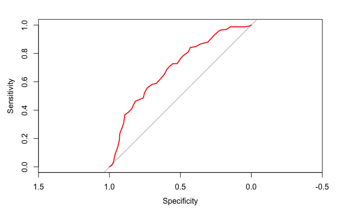

```r
library(pROC)
ROC.curve = roc(Dropout~Age, data = churndata)
plot(ROC.curve, col = "red")
```

- Area under the ROC curve ranges from 0.5 ro 1.
- Values above 0.8 indicate that the model does a good job in **discriminating between the two categories of the outcome variable**.

```r
# Area under the curve
auc(ROC.curve)
```

```
Area under the curve: 0.6982
```